# Multi-trait Analysis of GWAS Summary Statistics Using 'MTAFS' Package

Qiaolan Deng, Chi Song, Shili Lin

2022-05-14

# Overview

In genome-wide association studies (GWAS), the conventional single-trait analysis can lose statistical power given multiple correlated traits. Because it ignores the correlation among traits and the multiple testing correction is conservative. In contrast, multi-trait analysis methods can improve the power by exploiting the correlation among traits. Despite many existing multi-trait analysis methods using GWAS summary statistics, there are still several limitations. First, some methods cannot control type 1 error well at small significance levels. Second, many methods have inconsistent power performance under various scenarios. Third, methods relying on permutations can be time-consuming when extremely small p-values are required.

**MTAFS** is an efficient and robust method for multi-trait analysis of GWAS (Deng, Song, and Lin 2022). It uses GWAS summary statistics and construct its test statistic adaptively. Compared with many existing methods, MTAFS has three compelling features making it a useful method in practice. First, MTAFS can control type 1 error well even when there are hundreds of traits and significance levels are small. Second, MTAFS has robust power performance given various settings. Third, MTAFS is an efficient method by avoiding permutations.

This vignette provides an introduction to the multi-trait analysis of GWAS summary statistics using the 'MTAFS' package. R package 'MTAFS' implements the MTAFS method, an efficient and robust method for multi-trait analysis of GWAS. Users can find the most up-to-date versions of ‘MTAFS’ package in our GitHub webpage (https://github.com/Qiaolan/MTAFS).

The package can be installed and loaded with the command:

```r
#remotes::install_github("Qiaolan/MTAFS")
#devtools::load_all("~/rPackage/MTAFS")
library(MTAFS)
```

In this package, we provide the following main functions:

- **MTAFS**: the flagship function of the package, which requires z scores from GWAS summary statistics and returns p-values of MTAFS.
- **eigenDecomp**: conducts eigendecomposition on the estimated variance-covariance matrix $\hat{\mathbf R}$ and the output is used by `MTAFS`.

We illustrate the usage of these functions in the following sections.

# Introduction of Main Functions

Suppose there are $N$ SNPs and $T$ traits.

## `MTAFS`

`MTAFS` is the function that applys the MTAFS method and produces a matrix of p-values, described in detail below. It requires z scores from GWAS summary statistics and eigendecomposition results on $\hat{\mathbf R}$, output of the `eigenDecomp` function. The output consists of the p-values of using a specific number of eigenvalues and MTAFS.

The following show all the parameters in `MTAFS` function:

*MTAFS(Z, eigR, weights = NULL, snps = NULL, traits = NULL)*

`Z` is a $N \times T$ matrix of z scores obtained from GWAS summary statistics, where its row and column correspond to SNP and trait, respectively. `eigR` is the output of `eigenDecomp` function with two options: the default setting and the user-defined setting, described in detail in the next section. `weights` is a vector of weights for the Cauchy combination (Liu and Xie 2020). The defaul is `NULL` assuming a uniform weight. Note that the type 1 error control and power performance of non-uniform weights were not evaluated by either the original paper of Cauchy combination or our paper. `snps` is a vector of indices of SNPs of interest and we include all SNPs in `Z` by default. `traits` is a vector of indices of traits of interest and we include all traits in `Z` by default.

The output of `MTAFS` is a $N \times (L+1)$ matrix of p-values, where $L$ denotes the number of levels of variance explained. The first $L$ columns show the p-values obtained by using a specific number of eigenvalues (the percentage of variance explained is in the bracket) and the last column shows the p-values of MTAFS which is obtained by the Cauchy combination of the p-values of the first $L$ columns.

Here is an example of a partial z score matrix from an example dataset with five traits:

```r
data("gwasArea")
head(gwasArea[,1:5])
```

```
#>            1          2          3           4          5
#> 1 -0.1683913 -0.9690265  0.4954052 -0.28346457 -1.3239024
#> 2 -0.9791667 -0.2793296  1.0949868  0.04726368 -1.3672840
#> 3  0.1029412 -0.7788018 -1.0086957 -1.22540984  0.3451777
#> 4  1.3164903  1.3583815 -0.5888417 -1.46841955 -1.2248584
#> 5  0.3997454  1.6359281 -0.6035068  0.29317697 -0.5356671
#> 6 -1.4628062 -1.4662757 -0.8085443  0.41685309  0.8263279
```

## `eigenDecomp`

`eigenDecomp` conducts eigendecomposition on $\hat{\mathbf R}$. It calculates the levels of variance explained required by MTAFS (Deng, Song, and Lin 2022). In the default setting, we denote the proportion of variance explained by the first two eigenvalues as $v_0\%$. Then let $v_1\%$, $v_2\%$, and $v_3\%$ be the three percentages evenly distributed between $v_0\%$ and $100\%$, with $q_1$, $q_2$, and $q_3$ denoting the corresponding number of eigenvalues achieving the percent of variance explained for the first time. As a result, there are five levels of variance explained, with the corresponding number of eigenvalues being $2, q_1,q_2,q_3,T$.

The following show all the parameters in `eigenDecomp` function:

*eigenDecomp(estR, varExp=NULL)*

`estR` is the estimated variance-covariance matrix $\hat{\mathbf R}$. Linkage disequilibrium score regression (Bulik-Sullivan et al. 2015) or sample covariance (Zhu et al. 2015) can be used to get $\hat{\mathbf R}$.

`varExp` is a vector of user-defined percentage of variance explained. The default is NULL, which implements the default setting described above.

The output of `eigenDecomp` is a list containing the following components: `q` the number of eigenvectors that are included in the MTAFS analysis; `v` the corresponding percentage of variance explained; `eigenD` a list containing all eigenvalues and eigenvectors.

# An Example

In this vignette, we use an example GWAS summary statistics dataset consisting of $300$ SNPs and $212$ traits for the illustration purpose. The example dataset is a subset of the real dataset of 212 Area image-derived phenotypes in our paper (Deng, Song, and Lin 2022).

```r
data("gwasArea")
dim(gwasArea)
```

```
#> [1] 300 212
```

## Estimate $\mathbf R$

Under the null hypothesis, we assume $\mathbf Z \sim N(\mathbf 0, \mathbf R)$. For illustration, we use sample covariance to estimate $\mathbf R$, denoted as `Rhat`:

```r
Z <- gwasArea
Rhat <- cov(Z)
```

We show its correlation heatmap:

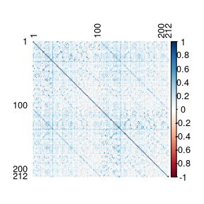

## Eigendecomposition

### The default setting

We conduct eigendecompositions on $\hat {\mathbf R}$ using `eigenDecomp`.

```r
eigR <- eigenDecomp(Rhat)
str(eigR)
```

```
#> List of 3
#>  $ q     : int [1:5] 2 7 19 44 212
#>  $ v     : num [1:5] 0.185 0.389 0.593 0.796 1
#>  $ eigenD:List of 2
#>   ..$ values : num [1:212] 27.34 11.93 9.79 8.59 7.67 ...
#>   ..$ vectors: num [1:212, 1:212] -0.08907 -0.09276 -0.06267 -0.00374 -0.10042 ...
#>   ..- attr(*, "class")= chr "eigen"
```

According to the output, we include the first 2, 7, 19, 44 and 212 eigenvectors to construct five levels. Also, the five numbers of eigenvectors explain $18.5\%$, $38.9\%$, $59.3\%$, $79.6\%$, and $100 \%$ of total variance. `eigR$eigenD$values` include all the eigenvalues and `eigR$eigenD$vectors` include all the eigenvectors.

### User-defined setting

Suppose we want to include the numbers of eigenvectors which explain $40\%$, $60\%$, and $80\%$ of the variance.

```r
eigR_user <- eigenDecomp(Rhat, varExp = c(0.4,0.6,0.8))
str(eigR_user)
```

```
#> List of 3
#>  $ q     : int [1:3] 8 20 45
#>  $ v     : num [1:3] 0.4 0.6 0.8
#>  $ eigenD:List of 2
#>   ..$ values : num [1:212] 27.34 11.93 9.79 8.59 7.67 ...
#>   ..$ vectors: num [1:212, 1:212] -0.08907 -0.09276 -0.06267 -0.00374 -0.10042 ...
#>   ..- attr(*, "class")= chr "eigen"
```

According to the output, we include the first $8$, $20$, and $45$ eigenvectors to construct three levels. Also, the three numbers of eigenvectors explain $40\%$, $60\%$, and $80 \%$ of total variance. `eigR$eigenD$values` include all the eigenvalues and `eigR$eigenD$vectors` include all the eigenvectors.

## MTAFS

### The default setting

Based on the default five levels, we construct the test statistic of MTAFS and calculate the final p-values for each SNPs by `MTAFS`:

```r
time=proc.time()
pMTAFS <- MTAFS(Z, eigR)
proc.time()-time
```

```
#>    user  system elapsed
#>  18.090   0.074  18.133
```

```r
head(pMTAFS)
```

```
#>         2(19%)     7(39%)    19(59%)    44(80%)  212(100%)      MTAFS
#> [1,] 0.5240083 0.87033627 0.83093106 0.42609214 0.11847370 0.58081372
#> [2,] 0.8470695 0.67864941 0.86318931 0.07713732 0.03552516 0.17361817
#> [3,] 0.9339750 0.99084049 0.98810115 0.35888951 0.08658312 0.97445614
#> [4,] 0.8528534 0.01514901 0.04164027 0.30207696 0.99999952 0.99999762
#> [5,] 0.7466172 0.33903347 0.71970859 0.88228203 0.12396586 0.58654713
#> [6,] 0.1810225 0.54673029 0.47053190 0.00532655 0.07994663 0.02437727
```

The output of `MTAFS` is a matrix of p-values, where its row corresponds to SNP. The first five columns consists of p-values obtained by using specific numbers (2, 7, 19, 44, and 212) of eigenvalues (inside brackets are the corresponding percentage of variance explained) and the last column are the p-values of MTAFS, based on which we can make a conclusion about the associations of interest.

### User-defined setting

We can also use the three levels in the user-defined setting.

```r
pMTAFS_user <- MTAFS(Z, eigR_user)
```

```r
head(pMTAFS_user)
```

```
#>          8(40%)    20(60%)     45(80%)      MTAFS
#> [1,] 0.66821686 0.86322424 0.460718377 0.72983170
#> [2,] 0.75419658 0.86058676 0.081364146 0.43060974
#> [3,] 0.98158732 0.98316578 0.377381405 0.97335382
#> [4,] 0.01454687 0.02467623 0.291741725 0.02683041
#> [5,] 0.42090699 0.69280498 0.901313777 0.77712030
#> [6,] 0.53938885 0.51808500 0.006997263 0.02104844
```

Since the user-defined setting has only three levels, now the output p-value matrix has only four columns in total. The first three columns consists of p-values obtained by using specific numbers (8, 20, and 45) of eigenvalues and the last column are the p-values of MTAFS, based on which we can make a conclusion about the associations of interest.

# Reference

Bulik-Sullivan, Brendan, Hilary K Finucane, Verneri Anttila, Alexander Gusev, Felix R Day, Po-Ru Loh, Laramie Duncan, et al. 2015. “An Atlas of Genetic Correlations Across Human Diseases and Traits.” *Nature Genetics* 47 (11). Nature Publishing Group: 1236–41.

Deng, Qiaolan, Chi Song, and Shili Lin. 2022. “An Adaptive and Robust Method for Multi-Trait Analysis of Genome-Wide Association Studies Using Summary Statistics.” *arXiv Preprint arXiv:2204.09751*.

Liu, Yaowu, and Jun Xie. 2020. “Cauchy Combination Test: A Powerful Test with Analytic P-Value Calculation Under Arbitrary Dependency Structures.” *Journal of the American Statistical Association* 115 (529). Taylor & Francis: 393–402.

Zhu, Xiaofeng, Tao Feng, Bamidele O Tayo, Jingjing Liang, J Hunter Young, Nora Franceschini, Jennifer A Smith, et al. 2015. “Meta-Analysis of Correlated Traits via Summary Statistics from Gwass with an Application in Hypertension.” *The American Journal of Human Genetics* 96 (1). Elsevier: 21–36.